# Linear Model in R: Analyzing Pollution Data in Madrid

Vivek Sinha

```
##
##  C:\Users\toviv\AppData\Local\Temp\RtmpSyX0Km\downloaded_packages
```

The work consists of analyzing a big dataset (72 csv files) with hourly pollution data from Madrid, from period 2011 to 2016. This dataset consists of several pollutants, whose measures are taken by different stations every hour.

The `weather` dataset is a time series consisting of minimum, maximum and average values of temperature, precipitation,humidity and wind speeds in Madrid.

**Part 1: Calling the Data**

Setting the Path

```r
Myfiles<-list.files(path = "D:/data/")
```

How all the csv files are stacked in a folder

[figure not shown]

Function to obtain filenames using month and year

```r
Read_Madrid_Data <- function(y, m) {
  ## Obtain filename of files for the year & month
  Myfiles <- paste0('hourly_data_', y, '_', m, '.csv')
## Load for this year/month
  z <- read.csv(Myfiles)
  z$date <- as.Date(paste0('20', y, '-', m, '-', z$day))
  z$day <- NULL
  return(z)
}
Entire_Madrid_Data <- function(ys,ms) {
  pollutants_H <- data.frame();
  for(y in ys) {
    for(m in ms) {

      monthly <- Read_Madrid_Data(y,m)
#Join
      pollutants_H <- rbind(pollutants_H, monthly )
    }
  }
  return(pollutants_H)
}

ys <- seq(11,16,1)
ms <-seq(1,12,1)

raw_data <- Entire_Madrid_Data(ys,ms)
```

How the raw data looks:

```r
head(raw_data)
```

```
##   hour  station parameter value       date
## 1    1 28079004         1     6 2011-01-01
## 2    1 28079008         1    12 2011-01-01
## 3    1 28079017         1    12 2011-01-01
## 4    1 28079018         1    10 2011-01-01
## 5    1 28079024         1     7 2011-01-01
## 6    1 28079035         1    11 2011-01-01
```

The following image shows the codes used in the `parameter` column belongs to which parameter

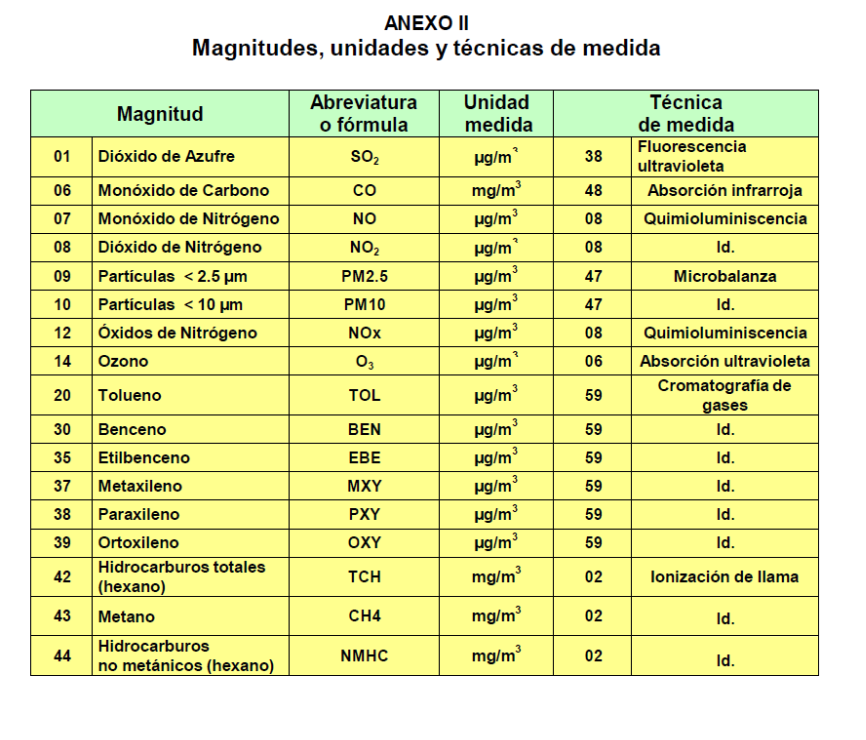

**Part 2: Cleaning Data**

```r
# Deleting irrelevant information
raw_data$station<-NULL

# Obtaining the mean of the parameters on a daily basis
rawdata2<-aggregate(raw_data[ ,'value'],mean, by= list(date1=raw_data$date,parameter2=raw_data$parameter), na.rm=T)
head(rawdata2)
```

```
##        date1 parameter2         x
## 1 2011-01-01          1 10.712500
## 2 2011-01-02          1 11.933333
## 3 2011-01-03          1 11.912134
## 4 2011-01-04          1  8.841667
## 5 2011-01-05          1  9.508403
## 6 2011-01-06          1  8.633333
```

Checking for Null Values

```r
sum(is.na(rawdata2))>0
```

```
## [1] FALSE
```

Reading the Weather File and viewing its data

```
##
##  C:\Users\toviv\AppData\Local\Temp\RtmpSyX0Km\downloaded_packages
```

```
## # A tibble: 6 x 7
##   Date2               temp_avg temp_max temp_min precipitation humidity
##   <dttm>                 <dbl>    <dbl>    <dbl>         <dbl>    <dbl>
## 1 2011-01-01 00:00:00      8.3     13        3            0          84
## 2 2011-01-02 00:00:00      8.6     13        4            0          81
## 3 2011-01-03 00:00:00      4.2      9.4     -1.6          0          86
## 4 2011-01-04 00:00:00      6.5      8        4.1          0          93
## 5 2011-01-05 00:00:00      8.9     10        6.3          0          90
## 6 2011-01-06 00:00:00     12.2     15        8.9          0.51       87
## # ... with 1 more variable: wind_avg_speed <dbl>
```

Filtering each relevant parameter, by setting the pollutant names on the basis of their code

```r
NO2 <- rawdata2[rawdata2$parameter2==8,]
SO2 <- rawdata2[rawdata2$parameter2==1,]
O3 <- rawdata2[rawdata2$parameter2==14,]
PM2.5 <- rawdata2[rawdata2$parameter2==9,]
```

And merge them with Entire_Data_Madrid

```r
rawdata3<-merge(NO2,SO2, by.x ='date1',by.y ='date1')
rawdata4<-merge(O3,PM2.5, by.x='date1',by.y='date1')
rawdata5<-merge(rawdata3,rawdata4, by.x='date1',by.y='date1')
```

Manually, renaming the columns

```r
colnames(rawdata5)[colnames(rawdata5)=="parameter2.x.x"] <- "NO2"
colnames(rawdata5)[colnames(rawdata5)=="x.x.x"] <- "avg_NO2"
colnames(rawdata5)[colnames(rawdata5)=="parameter2.y.x"] <- "SO2"
colnames(rawdata5)[colnames(rawdata5)=="x.y.x"] <- "avg_SO2"
colnames(rawdata5)[colnames(rawdata5)=="parameter2.x.y"] <- "O3"
colnames(rawdata5)[colnames(rawdata5)=="x.x.y"] <- "avg_O3"
colnames(rawdata5)[colnames(rawdata5)=="parameter2.y.y"] <- "PM2.5"
colnames(rawdata5)[colnames(rawdata5)=="x.y.y"] <- "avg_PM2.5"
```

And delete the irrelevant information

```r
rawdata5$try1.x.x<-NULL
rawdata5$i.x.x<-NULL
rawdata5$try1.y.x<-NULL
rawdata5$i.y.x<-NULL
rawdata5$try1.x.y<-NULL
rawdata5$i.x.y<-NULL
rawdata5$try1.y.y<-NULL
rawdata5$i.y.y<-NULL

str(rawdata5)
```

```
## 'data.frame':    2192 obs. of  9 variables:
##  $ date1    : Date, format: "2011-01-01" "2011-01-02" ...
##  $ NO2      : int  8 8 8 8 8 8 8 8 8 8 ...
##  $ avg_NO2  : num  41.5 48.5 63.6 46.3 51.5 ...
##  $ SO2      : int  1 1 1 1 1 1 1 1 1 1 ...
##  $ avg_SO2  : num  10.71 11.93 11.91 8.84 9.51 ...
##  $ O3       : int  14 14 14 14 14 14 14 14 14 14 ...
##  $ avg_O3   : num  20.47 15.56 9.45 13.34 10.88 ...
##  $ PM2.5    : int  9 9 9 9 9 9 9 9 9 9 ...
##  $ avg_PM2.5: num  9.36 9.08 11.94 9.4 10.51 ...
```

```r
str(weather)
```

```
## Classes 'tbl_df', 'tbl' and 'data.frame':    2192 obs. of  7 variables:
##  $ Date2         : POSIXct, format: "2011-01-01" "2011-01-02" ...
##  $ temp_avg      : num  8.3 8.6 4.2 6.5 8.9 12.2 10.9 9.8 8.4 6.9 ...
##  $ temp_max      : num  13 13 9.4 8 10 15 13 13 11 8.3 ...
##  $ temp_min      : num  3 4 -1.6 4.1 6.3 8.9 8.7 7.6 6.6 5.2 ...
##  $ precipitation : num  0 0 0 0 0 ...
##  $ humidity      : num  84 81 86 93 90 87 81 88 92 91 ...
##  $ wind_avg_speed: num  5.2 5.4 3.5 6.3 10.4 15.7 15.6 14.3 6.5 7.4 ...
```

Finally, merging the prepared data with the weather information

```r
library(lubridate)
weather$Date2 <- as.Date(weather$Date2)
```

Merged `rawdata5` which is the prepared `Entire_Madrid_Data` data and keeping the relevant variables for the final goal

```r
rawdata6<-merge(rawdata5,weather, by.x = 'date1',by.y ='Date2')
rawdata5$date1<-as.Date(rawdata5$date1)
rawdata6<-merge(rawdata5,weather, by.x = 'date1',by.y ='Date2')

rawdata6$temp_max<-NULL
rawdata6$temp_min<-NULL
rawdata6$humidity<-NULL
head(rawdata6)
```

```
##        date1 NO2  avg_NO2 SO2   avg_SO2 O3    avg_O3 PM2.5 avg_PM2.5 temp_avg
## 1 2011-01-01   8 41.51042   1 10.712500 14 20.473214     9  9.363636      8.3
## 2 2011-01-02   8 48.47396   1 11.933333 14 15.562500     9  9.076389      8.6
## 3 2011-01-03   8 63.63368   1 11.912134 14  9.446429     9 11.944444      4.2
## 4 2011-01-04   8 46.29514   1  8.841667 14 13.342262     9  9.402778      6.5
## 5 2011-01-05   8 51.51736   1  9.508403 14 10.883929     9 10.513889      8.9
## 6 2011-01-06   8 35.32812   1  8.633333 14 23.419643     9  6.979167     12.2
##   precipitation wind_avg_speed
## 1          0.00            5.2
## 2          0.00            5.4
## 3          0.00            3.5
## 4          0.00            6.3
## 5          0.00           10.4
## 6          0.51           15.7
```